# DataMining

Mikel Berganza

9/1/2021

## Lista de librerias utilizadas

```r
knitr::opts_chunk$set(echo = TRUE)
library(caret)
```

```r
library(mlbench)
library(ggplot2)
library(reshape2)
library(CatEncoders)
library(tidyverse)
library(DDoutlier)
library(caTools)
library(randomForest)
```

## Descripción del data set

El data set escogido es un data set para predecir el tipo de estrellas segun las diferentes caracteristicas de las mismas (https://www.kaggle.com/deepu1109/star-dataset).

El data set tiene las siguientes variables:

- Temperatura Absoluta de la estrella en Kelvin (K). Obtenido mediante la ley de desplazamiento de Wien para encontrar la temperatura de la corteza de una estrella mediante la longitud de onda.
- Luminosidad relativa de la estrella (L/Lo). Obtenido mediante la ley de Stefan-Boltzmann de radiación de cuerpos negros.
- Radio relativo de la estrella (R/Ro). Usando paralaje (parallax).
- Magnitud Absoluta de la estrella (Mv). Obtenido mediante la relacion de magnitud absoluta.
- Color de la estrella (blanca,roja,azul,amarilla,amarillo-naranja, etc).
- Clase espectral de la estrella (O,B,A,F,G,K,,M).
- Tipo de estrella:
  1. Brown Dwarf (Enana marrón) -> Tipo de estrella = 0
  2. Red Dwarf (Enana roja) -> Tipo de estrella = 1
  3. White Dwarf (Enana blanca) -> Tipo de estrella = 2
  4. Main Sequence (Secuencia principal) -> Tipo de estrella = 3
  5. Supergiant (Supergigantes) -> Tipo de estrella = 4
  6. Hypergiant (Hipergigantes) -> Tipo de estrella = 5

Los parametros Lo y Ro serian la media de luminosidad y de radio del sol: Lo = 3.828 x 10^26 Watts (Luminosidad media del sol) Ro = 6.9551 x 10^8 m (Radio medio del sol)

El proposito de los que han creado el conjunto de datos sería demostrar que las estrellas siguen una determinada gráfica en el espacio celeste, específicamente llamada Diagrama de Hertzsprung-Russell para que se pueda clasificar las estrellas trazando sus características basadas en esa gráfica.

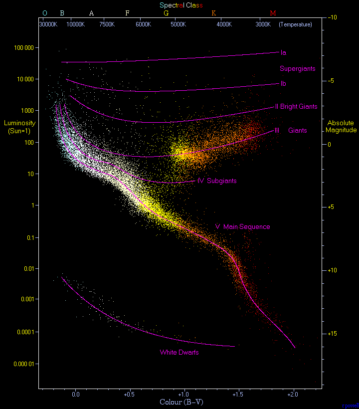

Imagen del Diagrama de Hertzsprung-Russell

El primer trozo de codigo en R es para cargar los datos, cambiar los tipos de estrella de numerico a nominal (para la parte de visualización) y mirar si hay valores faltantes.

```r
data<-read.csv("stars.csv", stringsAsFactors=FALSE)
#6 tipos diferentes de estrellas
#unique(data$Star.type)
starNums<-data$Star.type
#Lista de nombres del tipo de estrella
tipos<-c("Brown Dwarf", "Red Dwarf", "White Dwarf", "Main Sequence" , "SuperGiants", "HyperGiants")

#Cambiar todos los valores del tipo de estrella a nominal
for(i in 0:length(tipos)){
  #Indices que coinciden con el tipo de estrella i
  index<-which(data[,5]==i)
  #Asignar en esos indices el nombre
  data[index,5]<-tipos[i+1]
}
starsNombres<-data$Star.type
#Visualizar el encabezado de la base de datos
head(data)
```

```
##   Temperature..K. Luminosity.L.Lo. Radius.R.Ro. Absolute.magnitude.Mv.
## 1            3068         0.002400       0.1700                  16.12
## 2            3042         0.000500       0.1542                  16.60
## 3            2600         0.000300       0.1020                  18.70
## 4            2800         0.000200       0.1600                  16.65
## 5            1939         0.000138       0.1030                  20.06
## 6            2840         0.000650       0.1100                  16.98
##     Star.type Star.color Spectral.Class
## 1 Brown Dwarf        Red              M
## 2 Brown Dwarf        Red              M
## 3 Brown Dwarf        Red              M
## 4 Brown Dwarf        Red              M
## 5 Brown Dwarf        Red              M
## 6 Brown Dwarf        Red              M
```

```r
#Comprobavion de valores faltantes, haciendo una suma total
#de los valores faltantes de cada columna
missing<-sum(sapply(1:ncol(data),
                    FUN=function(r) {
                      sum(is.na(data[,r]))
                    }))

print(paste("Numero de valores faltantes:", missing))
```

```
## [1] "Numero de valores faltantes: 0"
```

## Graficas de visualizacion de las variables

En este apartado, se va a visualizar lo siguiente: * Primero, loss diferentes pares de variables. Para ver que tipo de relación puedan tener. * Las variables numericas respecto a la clase a predecir, para ver si hay alguna variable que pueda ser importante a la hora de clasificar la clase (distingue bien los tipos de estrellas). * La proporcion de cada clase espectral y color de todas las estrella.

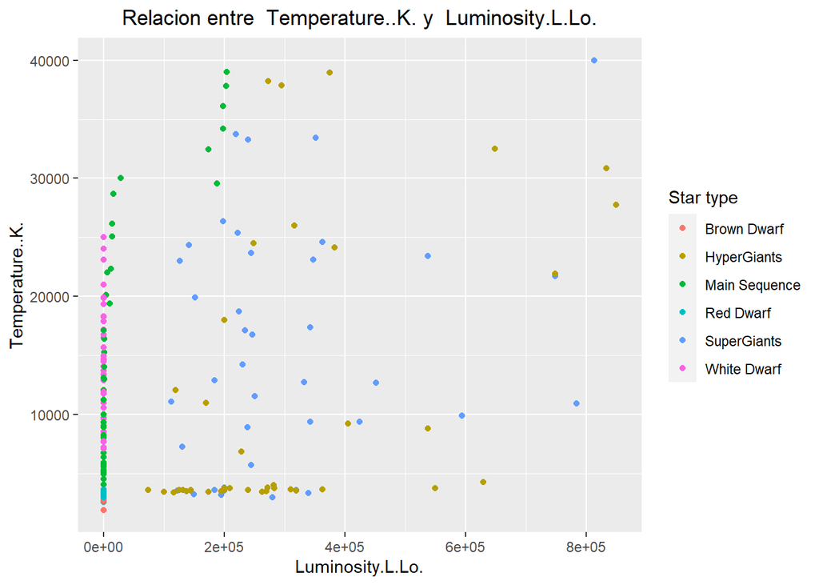

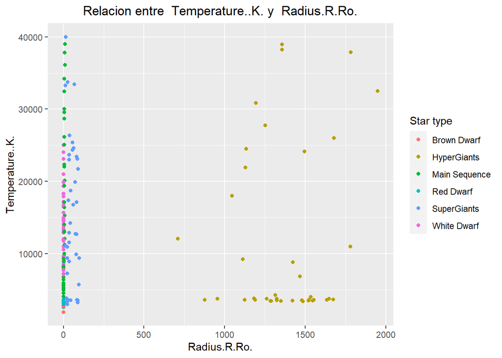

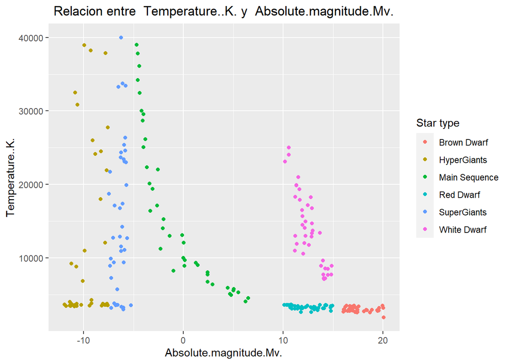

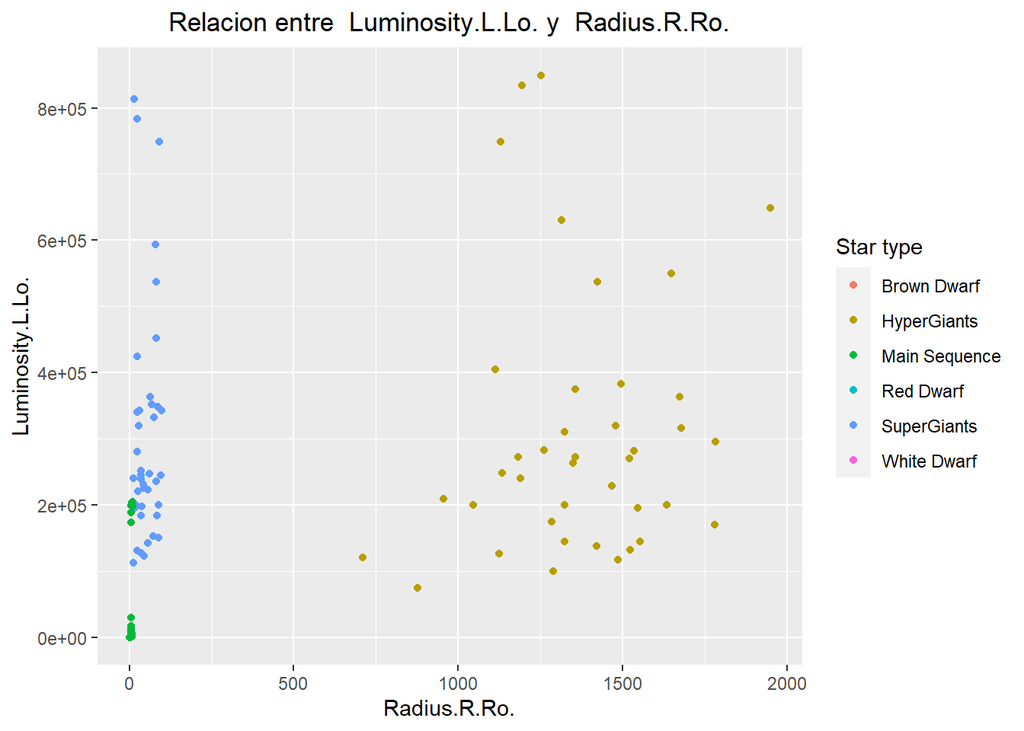

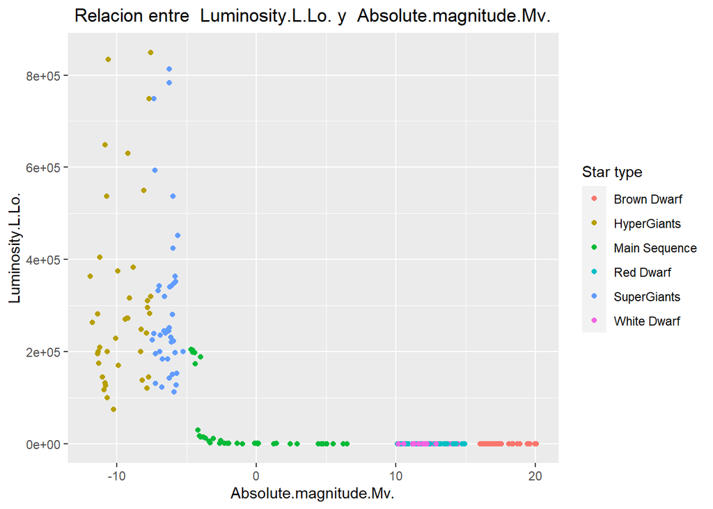

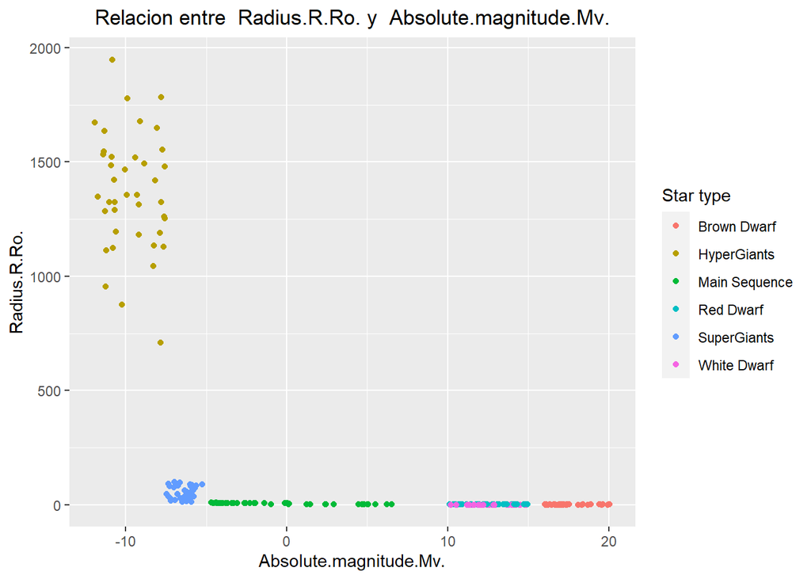

```r
#Plot entre las variables numericas excepto la clase
for (i in 1:3){
  for (j in (i+1):4){
    #Pasar a caracter la columna de clase para cojer 6 colores diferentes
    #en el parametro color
    print(ggplot(data = data) +
            geom_point(mapping = aes(x = data[,j], y = data[,i], color = as.character(Star.type))) +
            xlab(colnames(data)[j]) + ylab(colnames(data)[i]) +
            labs(color="Star type") +
            ggtitle(paste("Relacion entre ",colnames(data)[i],"y ",colnames(data)[j]))+
            theme(plot.title = element_text(hjust = 0.5)))
  }
}
```

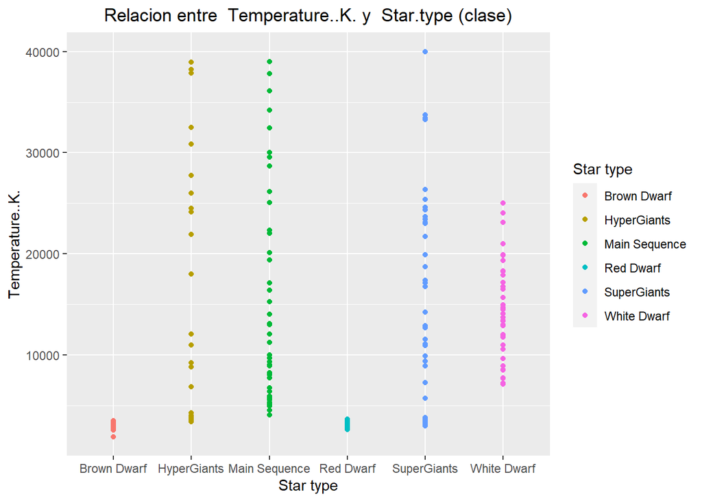

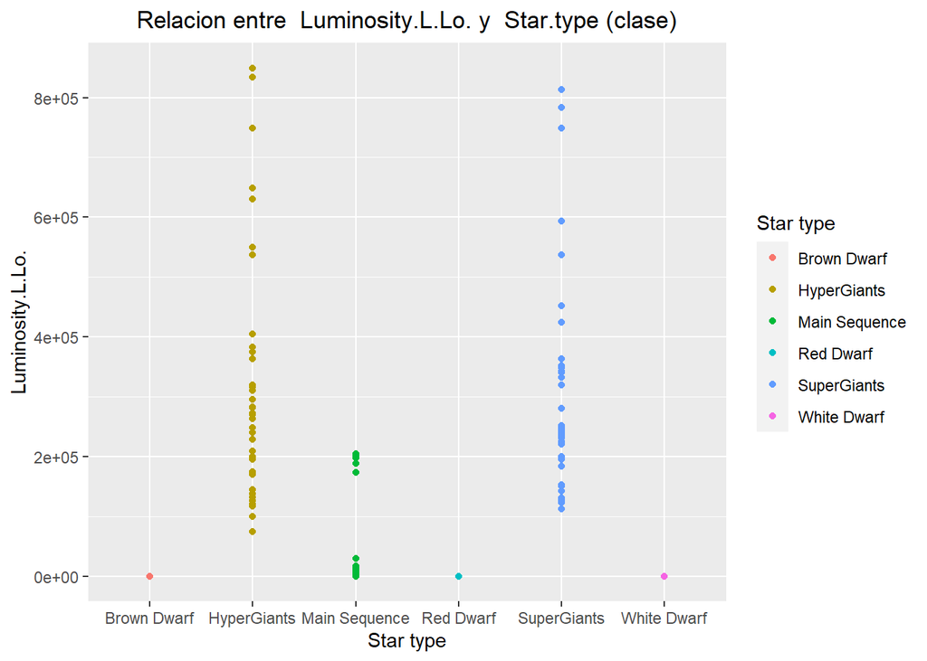

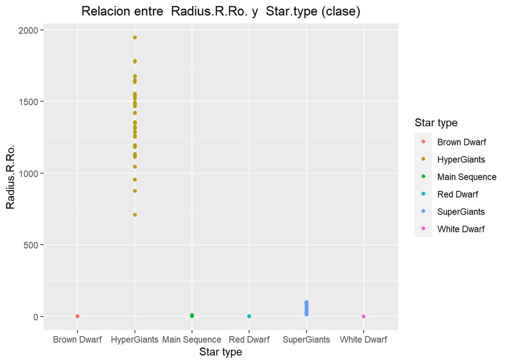

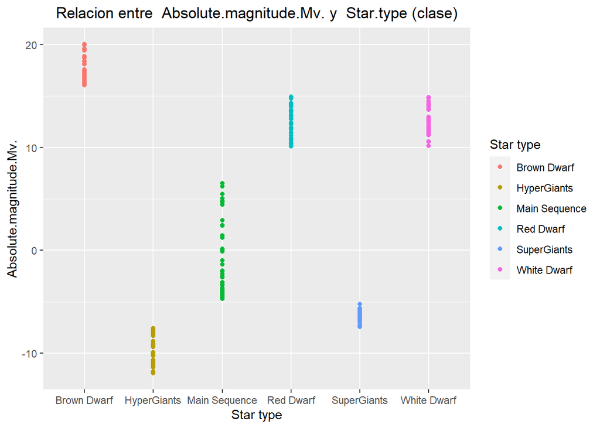

```r
#Plotear todas las variables con respecto a la clase
for (i in 1:4){
  print(ggplot(data = data) +
          geom_point(mapping = aes(x = data[,5], y = data[,i], color = as.character(Star.type))) +
          xlab("Star type") + ylab(colnames(data)[i]) +
          labs(color="Star type") +
          ggtitle(paste("Relacion entre ",colnames(data)[i],"y  Star.type (clase)"))+
          theme(plot.title = element_text(hjust = 0.5)))
}
```

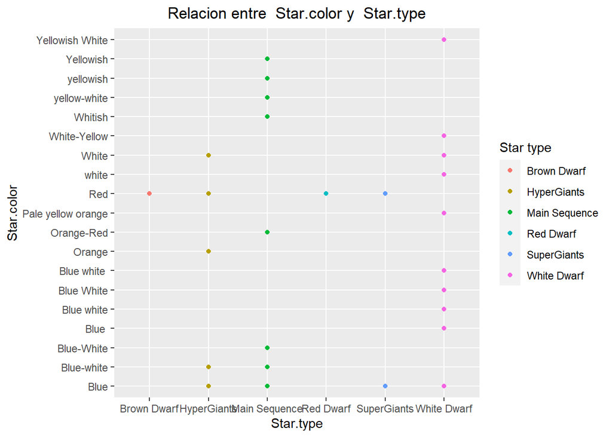

```r
#Plotear la variable de color con respecto a la clase
print(ggplot(data = data) +
        geom_point(mapping = aes(x = data[,5], y = data[,6], color = as.character(Star.type))) +
        xlab(colnames(data)[5]) + ylab(colnames(data)[6]) +
        labs(color="Star type") +
        ggtitle(paste("Relacion entre ",colnames(data)[6],"y ",colnames(data)[5]))+
        theme(plot.title = element_text(hjust = 0.5)))
```

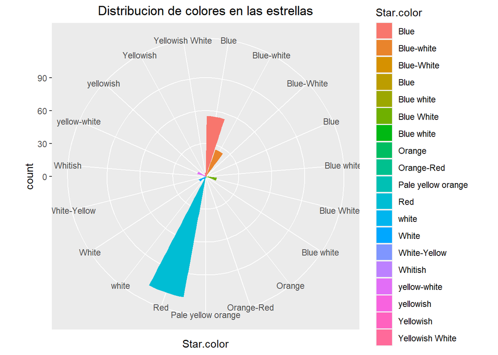

```r
#Plotear las dos variables nominales
ggplot(data = data) +
        geom_bar(mapping = aes(y = data[,6], fill = Star.color)) +
        ylab(colnames(data)[6]) +
        labs(color="Star type") +
        ggtitle(paste("Distribucion de colores en las estrellas"))+
        theme(plot.title = element_text(hjust = 0.5))+
        coord_polar("y", start=0)
```

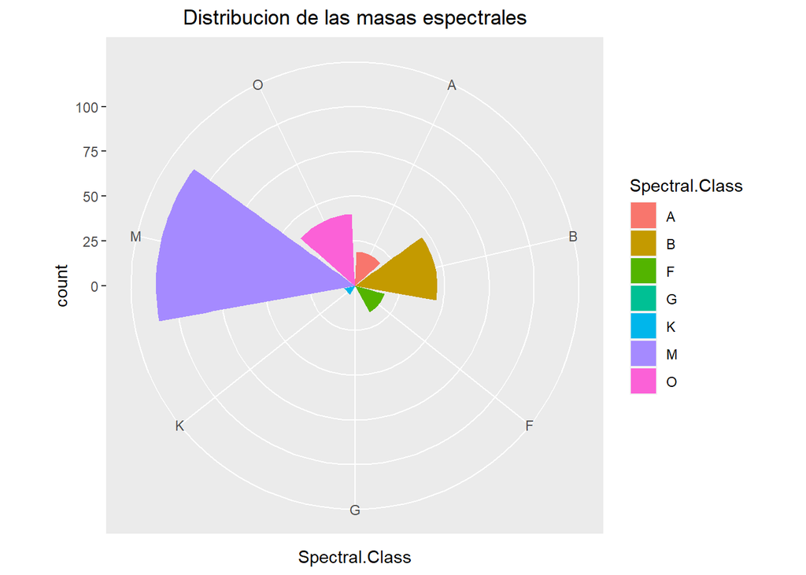

```r
ggplot(data = data) +
  geom_bar(mapping = aes(y = data[,7], fill = Spectral.Class)) +
  ylab(colnames(data)[7]) +
  labs(color="Masa Espectral") +
  ggtitle(paste("Distribucion de las masas espectrales"))+
  theme(plot.title = element_text(hjust = 0.5))+
  coord_polar("y", start=0)
```

Al observar los gráficos de relaciones entre las variables numericas, se puede ver como hay combinaciones que no aportan nada a la hora de diferenciar los tipos de estrellas, pero hay alguna que sí. Por ejemplo, las variables de temperatura y magnitud absoluta, consiguen una diferenciación perfecta de los tipos de estrellas. Las variables de luminosidad y radio en relación con la magnitud absoluta consiguen también una diferenciacion casi perfecta.

En la relación de variables respecto a la clase, parece que solo la variable de magnitud absoluta parece distinguir la mayoria (5) de tipos de estrella.

En los dos últimos gráficos, se pueden ver la distribucion de las variables nominales (color y masa espectral). De el gráfico de los colores, se puede decir que la mayoría (más de una tercera parte) de las estrellas observadas son de color rojo, y luego las seguirian las de color azul. Respecto a las masas espectrales, la mayoría parece ser de tipo M, y luego las seguirían las de tipo B.

## Densidad y Correlacion de variables

En este apartado, se van a comprobar las densidades de las diferentes variables (habiendo pasado las variables nominales a numericas) y luego la matriz de correlacion entre ellas.

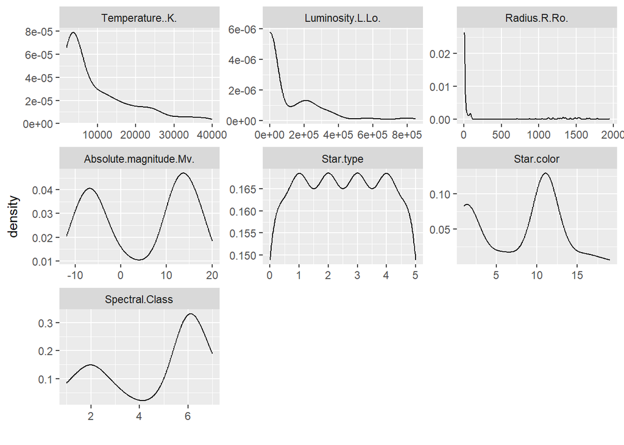

```r
#Como las ultimas dos columnas son categoricas, pasar a numericas
#para ver la correlacion
colorsOrder<-sort(unique(data$Star.color))
spectralOrder<-sort(unique(data$Spectral.Class))

#Crear nuevo dataset, para no modificar el original
dataNum<-data
#Pasar las columnas 6 y 7 (color y masa espectral) a numericas
#con el orden de numeros creado arriba (alfabetico)
dataNum$Star.color<-as.numeric(factor(dataNum$Star.color, colorsOrder))
dataNum$Spectral.Class<-as.numeric(factor(dataNum$Spectral.Class, spectralOrder))

#Devolver a numeros para calcular densidades y correlacion entre
#variables
dataNum[,5]<-starNums

#Juntar todos los datos
df <- melt(dataNum, measure.vars=1:ncol(dataNum))
#Plotear las densidades de cada variable
ggplot(df, aes(x=value)) + geom_line(stat="density") + facet_wrap(~variable, scales="free") + labs(x="")
```

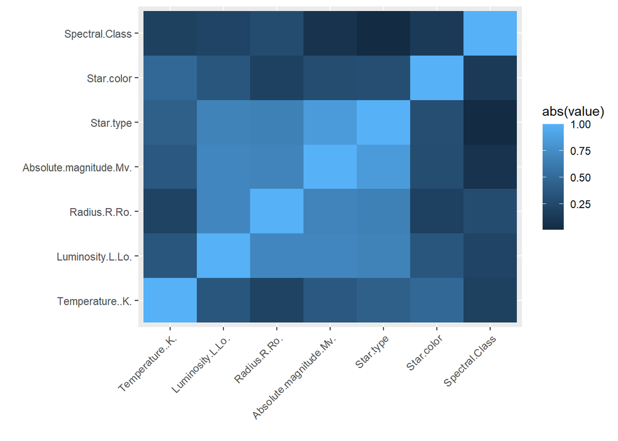

```r
#Densidades complejas, no Gaussianas.


#use="complete.obs" si hay valores faltantes
correlation.matrix <- cor(dataNum, method="kendall")
df2 <- melt(correlation.matrix)
ggplot(df2, aes(x=Var1, y=Var2, fill=abs(value))) + geom_tile() +
  labs(x="", y="") + theme(axis.text.x=element_text(angle=45, hjust=1))
```

En el gráfico de las densidades, se puede observar que hay alguna que otra densidad bimodal (magnitud absoluta, clase espectral), pero en general parecen tener densidades complejas.

En cuanto a las correlaciones, se puede ver que las variables mas coorreladas con el tipo de estrella son las variables de luminosidad, radio y magnitud absoluta, siendo esta última la que mejor relación tiene (como también se ha visto en los gráficos anteriores).

Las variables nominales no parecen tener mucha correlación con las demás.

## One Class Outlier Detection

En el apartado de One Class Outlier Detection, se va a separar cada tipo de estrella y luego buscar los posibles outliers de cada una mediante el algoritmo Local Outlier Factor (LOF) o Factor de Valor Atípico. El cual se basa en un concepto de densidad local, donde la localidad viene dada por k vecinos más cercanos, cuya distancia se usa para estimar la densidad. Al comparar la densidad local de un objeto con las densidades locales de sus vecinos, se pueden identificar regiones de densidad similar y puntos que tienen una densidad sustancialmente más baja que sus vecinos. Estos se consideran valores atípicos.

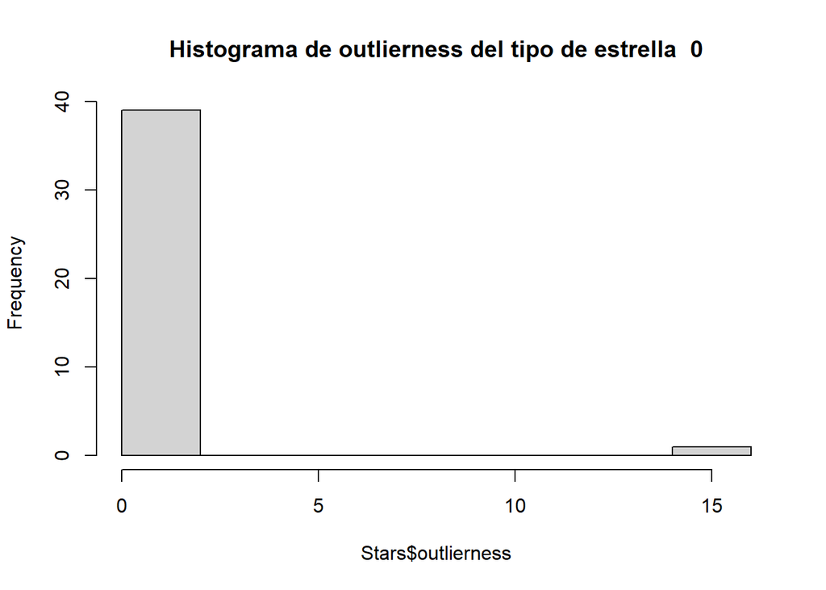

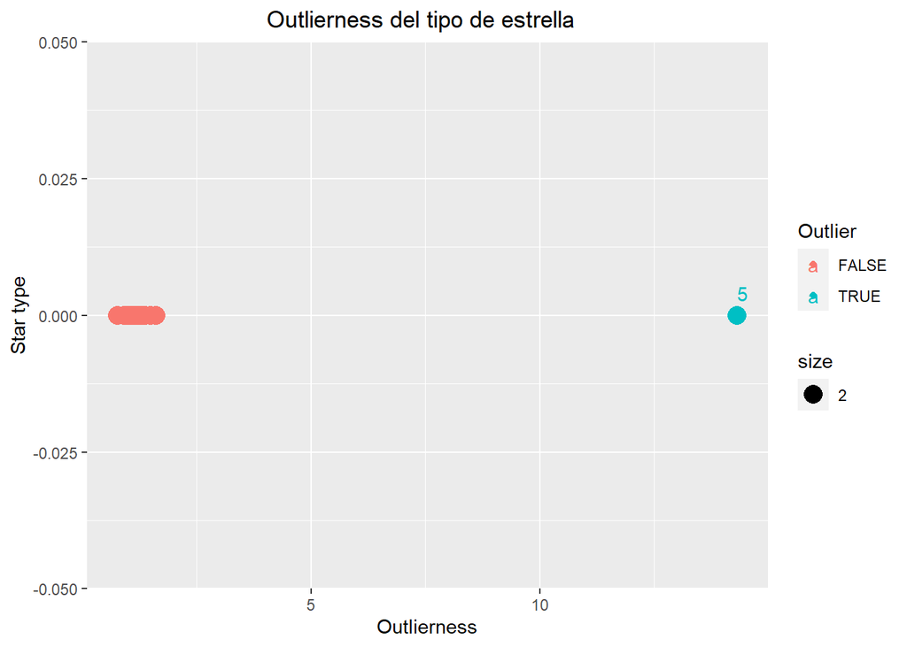

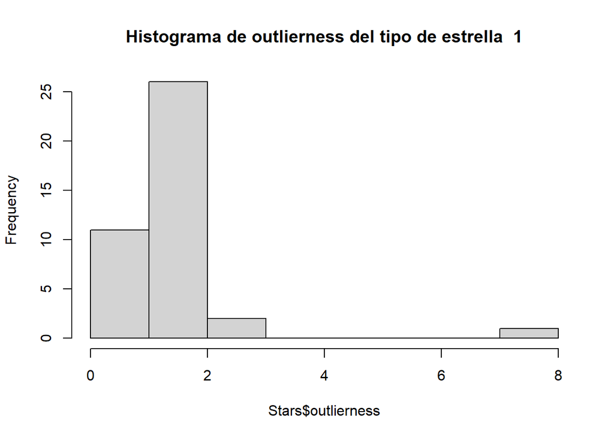

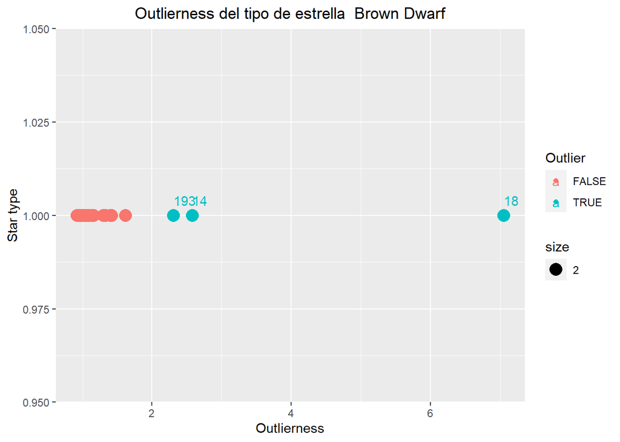

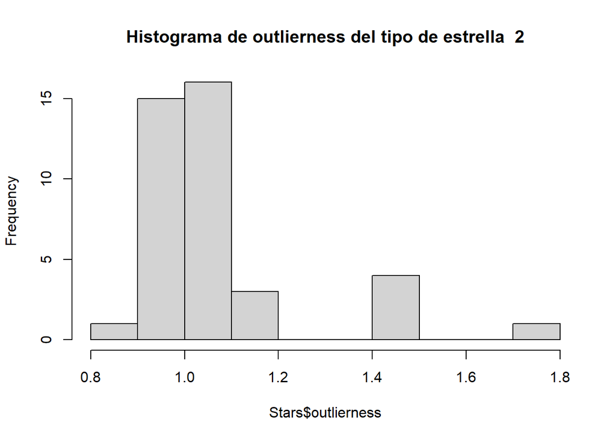

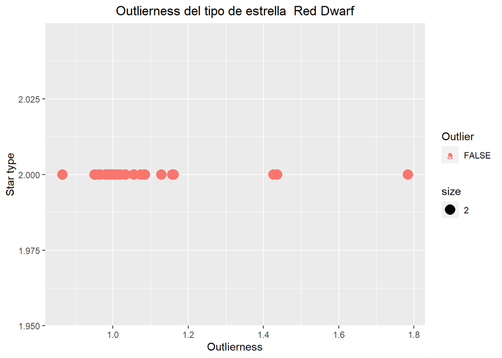

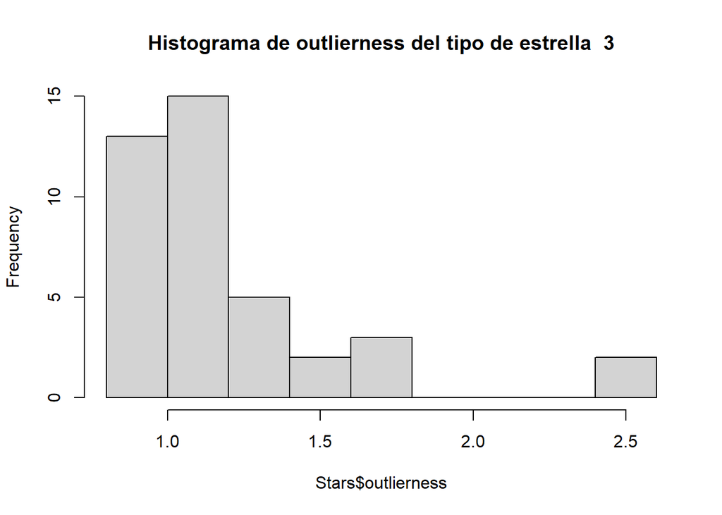

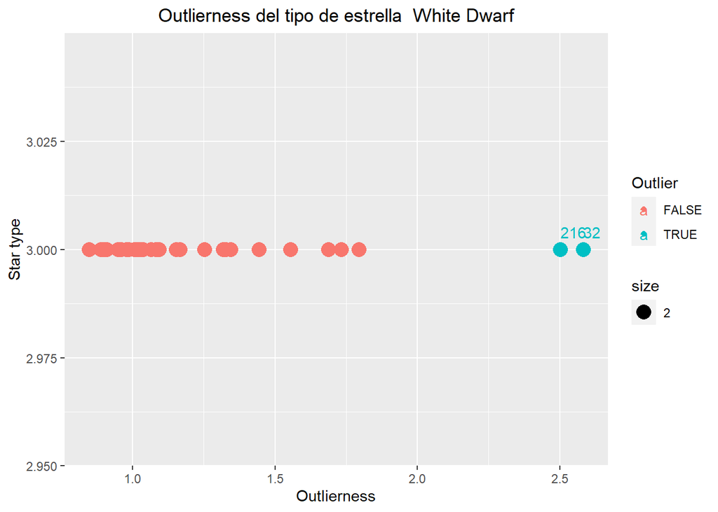

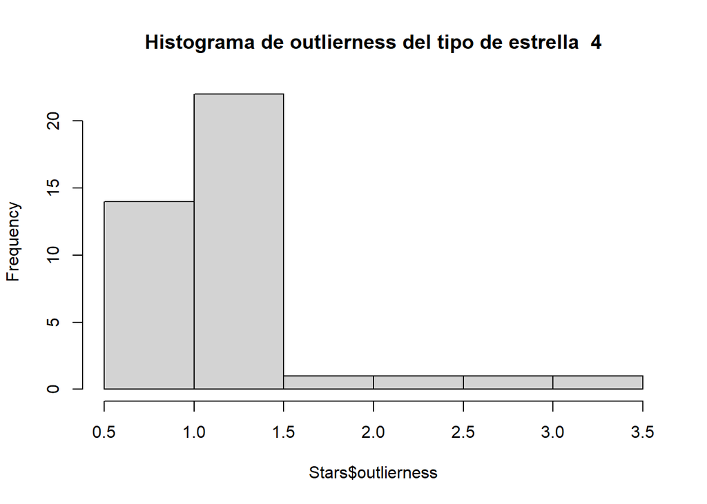

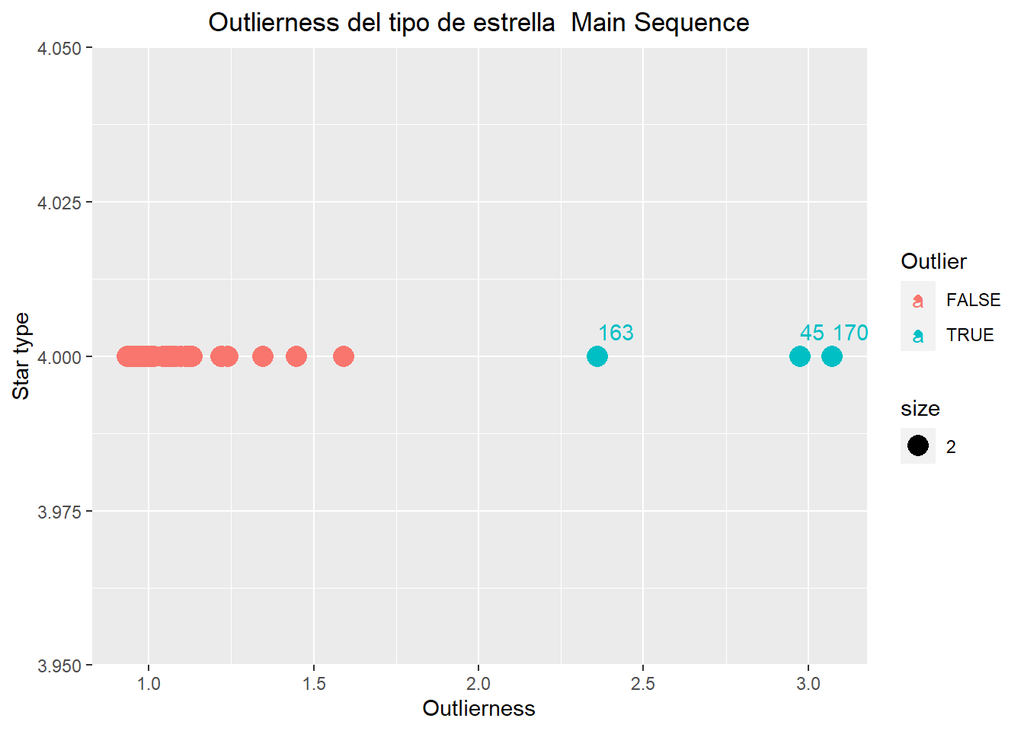

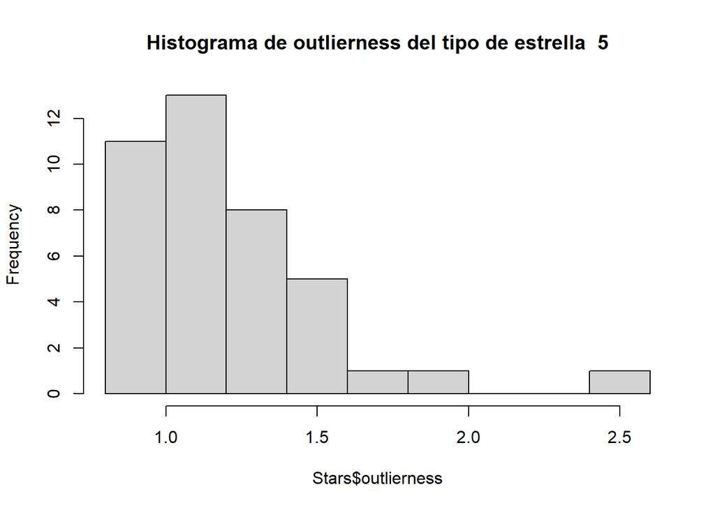

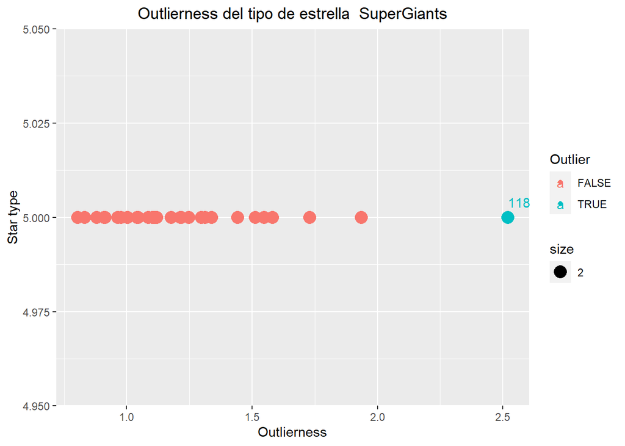

```r
data[,5]<-starNums
#One class outlier detection para los 6 tipos de estrellas
for (i in 0:5){
  Stars<-data[data$Star.type==i,]
  #Vector de strings vacios para poner a los valores normales
  #y que no salgan en el grafico los indices
  fake<-rep("", dim(Stars)[1])
  #Pasar como parametros las columnas numericas, no la de la clase
  Stars$outlierness<-LOF(Stars[,1:4], k=3)
  #sort(outlierness)
  #print(which(Stars$outlierness>2))
  #Crear columna nueva que dice si es o no un outlier dependiendo del
  #valor de outlierness obtenido
  Stars$outlier <-(Stars$outlierness>2)
  Stars$OutlierColor <- ifelse(Stars$outlier, "red", "black")
  hist(Stars$outlierness, main=paste("Histograma de outlierness del tipo de estrella ",i))
  #Scater plot de cada tipo de estrella y su outlierness
  print(ggplot(data = Stars) +
          geom_point(mapping = aes(x = Stars[,8], y = Stars[,5], color = outlier, size=2)) +
          xlab("Outlierness") + ylab("Star type") +
          labs(title=paste("Outlierness del tipo de estrella ",tipos[i]), color="Outlier") +
          theme(plot.title = element_text(hjust = 0.5))
          #Poner texto a los que sean outliers solo
          + geom_text(aes(x = Stars[,8], y = Stars[,5],
                          label=ifelse(Stars[,9]==TRUE ,row.names(Stars), fake),
                          color=outlier),hjust=0, vjust=-1))

  StarsVar <- paste("Star", i, sep = "")
  assign(StarsVar, Stars)
}
```

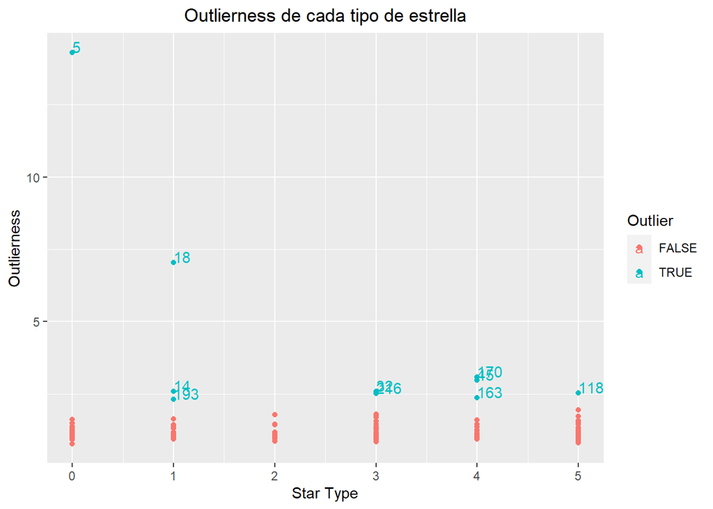

```r
Stars<-rbind(Star0, Star1, Star2, Star3, Star4, Star5)
fake<-rep("", dim(data)[1])
#Scater plot con los 5 tipos de estrella y su outlierness
print(ggplot(data = Stars) +
        geom_point(mapping = aes(x = Stars[,5], y = Stars[,8], color = outlier)) +
        xlab("Star Type") + ylab("Outlierness") +
        labs(color="Outlier") + ggtitle("Outlierness de cada tipo de estrella")+
        theme(plot.title = element_text(hjust = 0.5)) +
        #Poner texto a los que sean outliers solo
        geom_text(aes(x = Stars[,5], y = Stars[,8],
                       label= ifelse(Stars[,9]==TRUE ,row.names(Stars), fake),
                       color=outlier),hjust=0, vjust=0))
```

Al separar cada clase y mirar los valores atípicos de cada una, se puede ver que no hay muchos en general. Aquellos casos que superen un valor de outlierness de 2 (comparandose con los de su clase) son considerados outliers o valores atípicos.

Observando el gráfico final, los casos parecen estar bastante agrupados, y con el valor de corte de 2 parece que se diferencian bastante bien los outliers.

En este caso no se han utilizado los outliers para eliminar los casos de la base de datos, sino como una visualización para ver cuales podrían ser los outliers de esta base de datos.

## Principal Component Analysis

```r
#Particion de la base de datos en train y test con caTools
set.seed(999)
sample = sample.split(data$Temperature..K., SplitRatio = .80)
train = subset(data, sample == TRUE)
test  = subset(data, sample == FALSE)

#PCA
pcaT<-prcomp(train[,1:4], scale. = TRUE)
#Desviacion estandar de las componentes
pcaT$sdev
```

```
## [1] 1.5468765 0.9646933 0.6390086 0.5178878
```

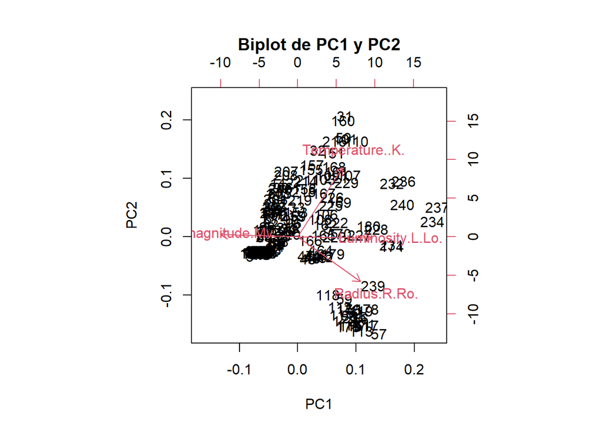

```r
#Plot de las dos componentes mas importantes y de las relaciones
#con las variables
biplot(pcaT, main="Biplot de PC1 y PC2")
```

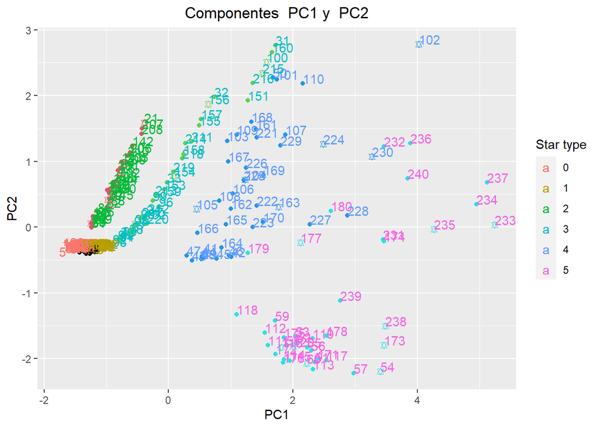

```r
pcaTrain<-as.data.frame(pcaT$x)
testPrediction<-as.data.frame(predict(pcaT, test[,1:4]))

#Plot de la base de datos de train y las predichas
#de la parte de test. Los puntos son de train, y las estrellas de test.
ggplot() +
  geom_point(data=train, mapping=aes(x=pcaTrain[, 1], y=pcaTrain[, 2]), color=as.character(train$Star.type), shape=19) +
  xlab(colnames(pcaTrain)[1]) + ylab(colnames(pcaTrain)[2]) +
  labs(color="Star type") +
  geom_text(aes(x=pcaTrain[, 1], y=pcaTrain[, 2],label=row.names(train), color=as.character(train$Star.type)),hjust=0, vjust=0)+
  ggtitle(paste("Componentes ",colnames(pcaTrain)[1],"y ",colnames(pcaTrain)[2]))+
  theme(plot.title = element_text(hjust = 0.5))+
  #Añadiendo los puntos a predecir
  geom_point(data=testPrediction, mapping=aes(x=testPrediction[, 1], y=testPrediction[, 2]), color=as.character(test$Star.type), shape=11) +
  geom_text(aes(x=testPrediction[, 1], y=testPrediction[, 2],label=row.names(testPrediction), color=as.character(test$Star.type)),hjust=0, vjust=0)
```

Como se puede observar en la imagen, en la cual los puntos representan los casos de entrenamiento y las estrellas representan los casos de prueba o test, se consigue una bastante buena diferenciación entre los 6 tipos de estrellas con las variables nuevas PC1 y PC2.

## Clasificación supervisada

En este apartado, se van a utilizar dos algoritmos de clasificación supervisada para después compararlos. En este caso, se han escogido los algoritmos de Multilayer Perceptron (MLP) y Random Forest (RF). El MLP, es una red neuronal artificial (RNA) formada por múltiples capas que tiene capacidad para resolver problemas que no son linealmente separables.

El funcionamiento básico sería el siguiente (para calcular la salida):

Las entradas se empujan hacia adelante a través del MLP tomando el producto escalar de la entrada con los pesos que existen entre la capa de entrada y la capa oculta (WH). Este producto escalar produce un valor en la capa oculta.

Se empuja la salida calculada en la capa actual (el valor anteriormente calculado) a través de cualquiera de las funciones de activación (Rectified Linear Units (ReLU), Sigmoid Function, tanh).

Al salir de la capa oculta, el proceso se repetiría asta llegar a la capa final o de salida. En la capa de salida, los cálculos se utilizarán para un algoritmo de retropropagación que corresponda a la función de activación que se seleccionó para el MLP (en el caso de entrenamiento) o se tomará una decisión basada en la salida (en el caso de prueba).

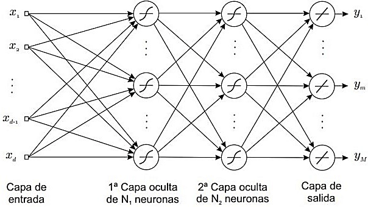

Imagen de un Multilayer Perceptron

El Random Forest o Bosques Aleatorios es una combinación de árboles predictores. Es un conjunto de árboles de decisión, generalmente entrenados con el método de “bagging”. La idea general del método de bagging es que una combinación de modelos de aprendizaje aumenta el resultado general.

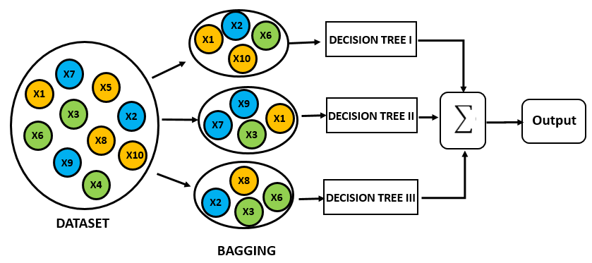

Imagen de un Random Forest

El único parámetro que tiene el random forest normal en caret es mtry (número de variables aleatorias como candidatas en cada ramifiación). En el caso del MLP, el único parámetro es size (número de unidades ocultas).

El parámetro tuneLength le dice al algoritmo que pruebe diferentes valores predeterminados para el parámetro principal.

El parámetro tuneGrid permite decidir qué valores tomará el parámetro principal, mientras que tuneLength solo limita el número de parámetros predeterminados a utilizar.

Como la base de datos no tiene valores faltantes, las unicas opciones utilizadas en el parametro preProc (preprocesar los datos) serán los de centrado y escalado.

```r
dataNum[,5]<-starsNombres
set.seed(999)
sample = sample.split(data$Temperature..K., SplitRatio = .80)
#Utilizar los datos con las variables nominales factorizadas
train = subset(dataNum, sample == TRUE)
test  = subset(dataNum, sample == FALSE)
#train<-subset(train, select=-c(6,7))
#test<-subset(test, select=-c(6,7))
train<-subset(train, select=-6)
test<-subset(test, select=-6)
#Pasar a caracteres las classes a predecir
test[,5]<-as.character(test[,5])
#Comprobar que no es clase numerica
is.numeric(test[,5])
```

```
## [1] FALSE
```

```r
#?trainControl
trainCont<-trainControl(method="boot", number=20)

#?train
multiLayerPerceptronModelBOOT <- train (Star.type ~ ., data=train,
                                        method="mlp",
                                        trControl=trainCont,
                                        preProc=c("center","scale"),
                                        metric="Accuracy",
                                        tuneLength=10)

multiLayerPerceptronModelBOOT
```

```
## Multi-Layer Perceptron
##
## 192 samples
##   5 predictor
##   6 classes: 'Brown Dwarf', 'HyperGiants', 'Main Sequence', 'Red Dwarf', 'SuperGiants', 'White Dwarf'
##
## Pre-processing: centered (5), scaled (5)
## Resampling: Bootstrapped (20 reps)
## Summary of sample sizes: 192, 192, 192, 192, 192, 192, ...
## Resampling results across tuning parameters:
##
##   size  Accuracy   Kappa
##    1    0.4105122  0.3070425
##    3    0.9464341  0.9352737
##    5    0.9747750  0.9695217
##    7    0.9792519  0.9749091
##    9    0.9785105  0.9740030
##   11    0.9797394  0.9754976
##   13    0.9820312  0.9782653
##   15    0.9792471  0.9749159
##   17    0.9820671  0.9783178
##   19    0.9783761  0.9738900
##
## Accuracy was used to select the optimal model using the largest value.
## The final value used for the model was size = 17.
```

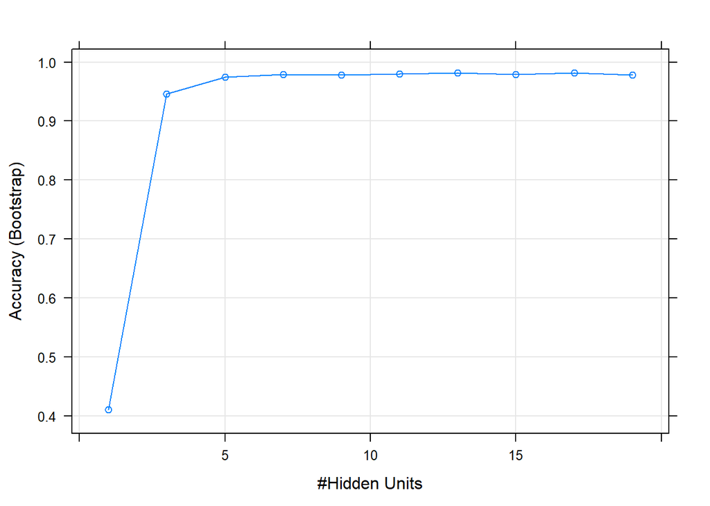

```r
plot(multiLayerPerceptronModelBOOT)
```

```r
#?predict
#Predecir la clase, sin probabilidades, la que mayor probabilidad tenga se asigna.
#Como devuelve numeros enteros, pasar a enteros redondeando y factorizar
predictionsMLP <- factor(predict(multiLayerPerceptronModelBOOT,test, type = "raw"))
confusionMatrix(data=predictionsMLP,factor(test$Star.type))
```

```
## Confusion Matrix and Statistics
##
##                Reference
## Prediction      Brown Dwarf HyperGiants Main Sequence Red Dwarf SuperGiants
##   Brown Dwarf            12           0             0         0           0
##   HyperGiants             0           9             0         0           0
##   Main Sequence           0           0             6         0           0
##   Red Dwarf               0           0             0         6           0
##   SuperGiants             0           0             0         0           6
##   White Dwarf             0           0             0         0           0
##                Reference
## Prediction      White Dwarf
##   Brown Dwarf             0
##   HyperGiants             0
##   Main Sequence           0
##   Red Dwarf               0
##   SuperGiants             0
##   White Dwarf             9
##
## Overall Statistics
##
##                Accuracy : 1
##                  95% CI : (0.926, 1)
##     No Information Rate : 0.25
##     P-Value [Acc > NIR] : < 2.2e-16
##
##                   Kappa : 1
##
##  Mcnemar's Test P-Value : NA
##
## Statistics by Class:
##
##                      Class: Brown Dwarf Class: HyperGiants Class: Main Sequence
## Sensitivity                        1.00             1.0000                1.000
## Specificity                        1.00             1.0000                1.000
## Pos Pred Value                     1.00             1.0000                1.000
## Neg Pred Value                     1.00             1.0000                1.000
## Prevalence                         0.25             0.1875                0.125
## Detection Rate                     0.25             0.1875                0.125
## Detection Prevalence               0.25             0.1875                0.125
## Balanced Accuracy                  1.00             1.0000                1.000
##                      Class: Red Dwarf Class: SuperGiants Class: White Dwarf
## Sensitivity                     1.000              1.000             1.0000
## Specificity                     1.000              1.000             1.0000
## Pos Pred Value                  1.000              1.000             1.0000
## Neg Pred Value                  1.000              1.000             1.0000
## Prevalence                      0.125              0.125             0.1875
## Detection Rate                  0.125              0.125             0.1875
## Detection Prevalence            0.125              0.125             0.1875
## Balanced Accuracy               1.000              1.000             1.0000
```

```r
###############################Metodo 2################################

#?trainControl
rfTrain<-trainControl(method="optimism_boot", number=20,
                        search="random")

#?train
randForest <- train (Star.type ~ ., data=train,
                                        method = 'rf',
                                        trControl=rfTrain,
                                        preProc=c("center","scale"),
                                        tuneLength=5)

predictionsRF <- factor(predict(randForest,test, type = "raw"))
confusionMatrix(data=predictionsRF,factor(test$Star.type))
```

```
## Confusion Matrix and Statistics
##
##                Reference
## Prediction      Brown Dwarf HyperGiants Main Sequence Red Dwarf SuperGiants
##   Brown Dwarf            12           0             0         0           0
##   HyperGiants             0           9             0         0           0
##   Main Sequence           0           0             6         0           0
##   Red Dwarf               0           0             0         6           0
##   SuperGiants             0           0             0         0           6
##   White Dwarf             0           0             0         0           0
##                Reference
## Prediction      White Dwarf
##   Brown Dwarf             0
##   HyperGiants             0
##   Main Sequence           0
##   Red Dwarf               0
##   SuperGiants             0
##   White Dwarf             9
##
## Overall Statistics
##
##                Accuracy : 1
##                  95% CI : (0.926, 1)
##     No Information Rate : 0.25
##     P-Value [Acc > NIR] : < 2.2e-16
##
##                   Kappa : 1
##
##  Mcnemar's Test P-Value : NA
##
## Statistics by Class:
##
##                      Class: Brown Dwarf Class: HyperGiants Class: Main Sequence
## Sensitivity                        1.00             1.0000                1.000
## Specificity                        1.00             1.0000                1.000
## Pos Pred Value                     1.00             1.0000                1.000
## Neg Pred Value                     1.00             1.0000                1.000
## Prevalence                         0.25             0.1875                0.125
## Detection Rate                     0.25             0.1875                0.125
## Detection Prevalence               0.25             0.1875                0.125
## Balanced Accuracy                  1.00             1.0000                1.000
##                      Class: Red Dwarf Class: SuperGiants Class: White Dwarf
## Sensitivity                     1.000              1.000             1.0000
## Specificity                     1.000              1.000             1.0000
## Pos Pred Value                  1.000              1.000             1.0000
## Neg Pred Value                  1.000              1.000             1.0000
## Prevalence                      0.125              0.125             0.1875
## Detection Rate                  0.125              0.125             0.1875
## Detection Prevalence            0.125              0.125             0.1875
## Balanced Accuracy               1.000              1.000             1.0000
```

Como se puede observar en los resultados obtenidos, los dos modelos consiguen un 100% de aciertos, esto puede ser debido a que las variables diferencian bien los tipos de estrellas, y la clasificación es clara (como se podía ver en los gráficos, habian variables que diferenciaban bien entre los tipos de estrellas).

Los mejores valores obtenidos por el parametro tuneLength han sido 17 unidades ocultas para el MLP y 4 variables aleatorias como candidatas en cada ramifiación para el RF.

## Comparacion de los modelos de Clasificación Supervisada

En este apartedo se van a comparar los dos modelos seleccionados mediante un gráfico de porcentaje de aciertos.

```r
#?resamples
#Los dos modelos tienen que tener el mismo numero de resamples en
#el parametro number de trainControl
resamps=resamples(list(mlp=multiLayerPerceptronModelBOOT,rf=randForest))
summary(resamps)
```

```
##
## Call:
## summary.resamples(object = resamps)
##
## Models: mlp, rf
## Number of resamples: 20
##
## Accuracy
##          Min.   1st Qu.    Median      Mean 3rd Qu. Max. NA's
## mlp 0.9436620 0.9704484 0.9855042 0.9820671       1    1    0
## rf  0.9714286 0.9969136 1.0000000 0.9959391       1    1    0
##
## Kappa
##          Min.   1st Qu.    Median      Mean 3rd Qu. Max. NA's
## mlp 0.9322034 0.9639392 0.9825002 0.9783178       1    1    0
## rf  0.9655766 0.9962673 1.0000000 0.9950933       1    1    0
```

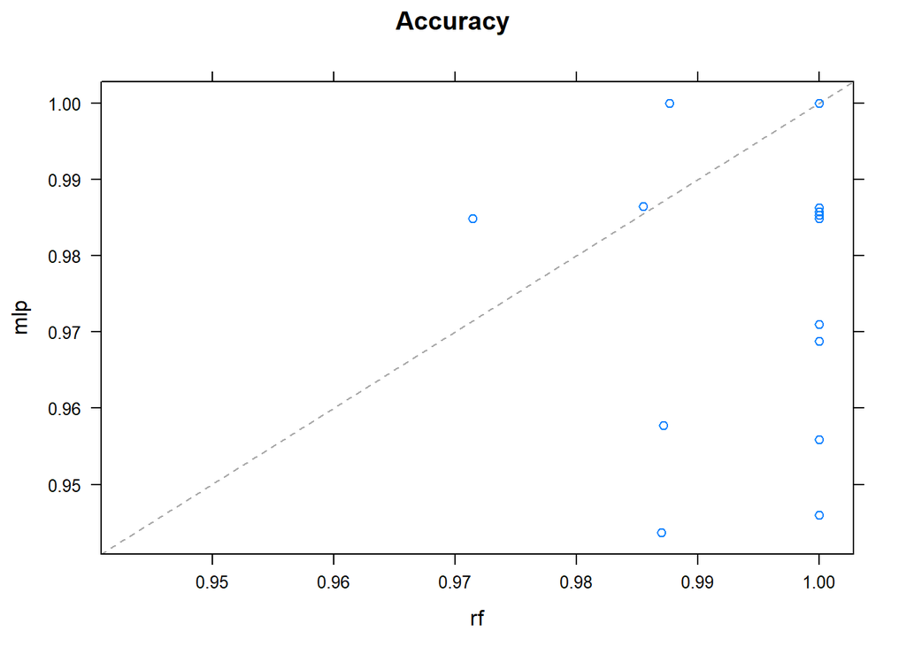

```r
#?xyplot
xyplot(resamps)
```

```r
diffs<-diff(resamps)
summary(diffs)
```

```
##
## Call:
## summary.diff.resamples(object = diffs)
##
## p-value adjustment: bonferroni
## Upper diagonal: estimates of the difference
## Lower diagonal: p-value for H0: difference = 0
##
## Accuracy
##     mlp      rf
## mlp          -0.01387
## rf  0.004347
##
## Kappa
##     mlp      rf
## mlp          -0.01678
## rf  0.004232
```